# Segmentacja części garderoby ludzi na obrazach

Projekt na zaliczenie przedmiotu Automatyczna analiza obrazu

Autor

Piotr Szyszka  
Inżynieria i Analiza danych 2022/23  
s95047@pollub.edu.pl

Opublikowano

29 czerwca 2023

# Wprowadzenie

Raport przedstawia projekt opracowania modelu uczenia maszynowego dotyczącego segmentacji ubrań na obrazach. W celu precyzyjnego rozgraniczenia różnych części odzieży na obrazie, zbudowane i porównane zostały trzy architektury oparte na konwolucyjnych sieciach neuronowych. Modelowanie wykonane zostało w języku programowania R z wykorzystaniem biblioteki [tensorflow](https://tensorflow.rstudio.com/).

# Problem i cel badawczy

Tradycyjne metody segmentacji często nie są wystarczająco precyzyjne i nie radzą sobie ze złożonymi wzorami, strukturami i zmiennością w ubraniach. W tym kontekście, sieci neuronowe, a szczególnie sieci konwolucyjne, wykazują potencjał do efektywnej segmentacji ubrań, ponieważ są w stanie wykrywać i rozpoznawać wzorce na różnych poziomach abstrakcji.

Głównym celem projektu jest opracowanie i zastosowanie zaawansowanych technik sieci neuronowych do segmentacji ubrań na obrazach. W szczególności, celem jest stworzenie modelu, który będzie w stanie z dostateczną dokładnością wyodrębnić poszczególne części odzieży, takie jak rękawy, spódnice, koszule itp.

Zastosowania modeli sieci neuronowych w segmentacji ubrań są szerokie i obejmują wiele dziedzin. Są to między innymi:

- automatyczne wyodrębnianie i prezentacja róznych części garderoby w sklepach internetowych - dzięki temu potencjalni klienci mogą łatwo zobaczyć, jak dana część garderoby wygląda w rzeczywistości, co może zwiększyć atrakcyjność sklepu i poprawić doświadczenie zakupowe;
- modele segmentacji ubrań mogą być wykorzystane do tworzenia wirtualnych przymierzalni. Umożliwiają one klientom wirtualne przymierzenie ubrań bez konieczności fizycznego przymierzania ich. Dzięki segmentacji ubrań można dokładnie wyodrębnić różne części garderoby i odpowiednio nałożyć je na model wirtualny, aby uzyskać realistyczny efekt;
- przetwarzanie obrazów - ozwala to użytkownikom na wyodrębnienie konkretnych części ubioru, np. sukienki, spodni czy butów, co ułatwia identyfikację i wyszukiwanie konkretnych produktów;
- analiza trendów w modzie - segmentacja ubrań przy użyciu modeli sieci neuronowych pozwala śledzić popularność i występowanie konkretnych wzorów, krojów czy stylów na podstawie segmentacji ubrań w różnych kolekcjach, na wybiegach mody czy w mediach społecznościowych. Takie informacje mogą być cenne dla projektantów mody, producentów ubrań i marketerów;
- automatyzacja procesów przemysłowych - wykorzystanie segmentacji ubrań w przemyśle odzieżowym może znacznie usprawnić procesy produkcyjne, kontrolę jakości oraz zarządzanie zapasami. Automatyczne wyodrębnienie i rozgraniczenie poszczególnych części odzieży pozwala na bardziej precyzyjne określenie, na którym etapie produkcji mogą wystąpić wady lub niezgodności. To z kolei przyczynia się do skrócenia czasu produkcji i zmniejszenia kosztów.

Segmentacja ubrań na obrazach przez sieci neuronowe ma wiele praktycznych zastosowań. Poprawia doświadczenie użytkowników, umożliwia analizę trendów, automatyzuje procesy produkcyjne i wiele innych. Dlatego kontynuowanie badań i rozwoju w tym obszarze jest ważne dla dalszego postępu w dziedzinie automatycznej analizy obrazu i rozwoju innowacyjnych rozwiązań w różnych branżach.

# Opis zbioru badawczego

[Zbiór danych](https://www.kaggle.com/datasets/rajkumarl/people-clothing-segmentation), który posłużył budowie sieci pochodzi z platformy [kaggle](https://www.kaggle.com/). Zawiera 1000 obrazów i 1000 odpowiadających im masek, każdy o rozmiarze (825px x 550px). Maski segmentacji należą do 59 klas, z czego pierwsza jest tłem osób, a pozostałe należą do 58 klas odzieżowych, takich jak koszula, włosy, spodnie, skóra, buty, okulary i inne. Zestaw danych zawiera dane w formatach JPEG i PNG.

| ID | label |
| --- | --- |
| 0 | null |
| 1 | accessories |
| 2 | bag |
| 3 | belt |
| 4 | blazer |
| 5 | blouse |
| 6 | bodysuit |
| 7 | boots |
| 8 | bra |
| 9 | bracelet |
| 10 | cape |
| 11 | cardigan |
| 12 | clogs |
| 13 | coat |
| 14 | dress |
| 15 | earrings |
| 16 | flats |
| 17 | glasses |
| 18 | gloves |
| 19 | hair |
| 20 | hat |
| 21 | heels |
| 22 | hoodie |
| 23 | intimate |
| 24 | jacket |
| 25 | jeans |
| 26 | jumper |
| 27 | leggings |
| 28 | loafers |
| 29 | necklace |

| ID | label |
| --- | --- |
| 30 | panties |
| 31 | pants |
| 32 | pumps |
| 33 | purse |
| 34 | ring |
| 35 | romper |
| 36 | sandals |
| 37 | scarf |
| 38 | shirt |
| 39 | shoes |
| 40 | shorts |
| 41 | skin |
| 42 | skirt |
| 43 | sneakers |
| 44 | socks |
| 45 | stockings |
| 46 | suit |
| 47 | sunglasses |
| 48 | sweater |
| 49 | sweatshirt |
| 50 | swimwear |
| 51 | t-shirt |
| 52 | tie |
| 53 | tights |
| 54 | top |
| 55 | vest |
| 56 | wallet |
| 57 | watch |
| 58 | wedges |

Słownik kategorii i odpowiadających im etykiet

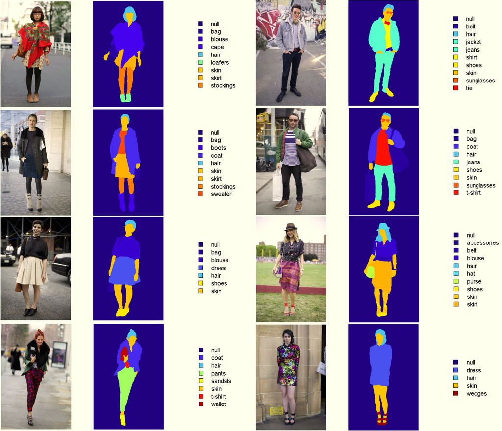

Przykładowe instancje zbioru badawczego

# Proponowane rozwiązanie

Zbudowane zostały trzy architektury sieci neuronowych. Są to:

- architektura oparta o sieć `DenseNet121` z odmrożonymi wszystkimi warstwami:

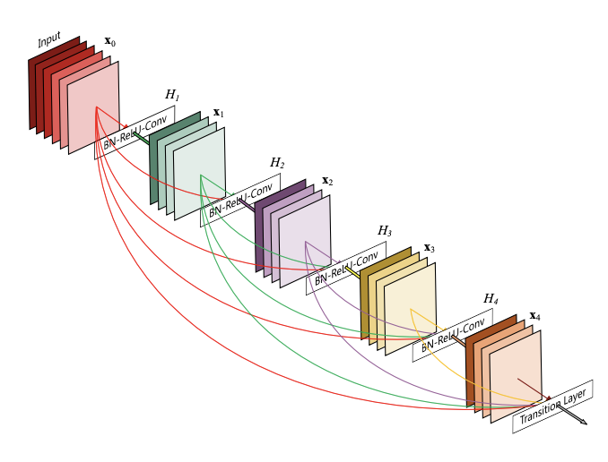

Przykład sieci Dense

Zbudowana sieć jest postaci:

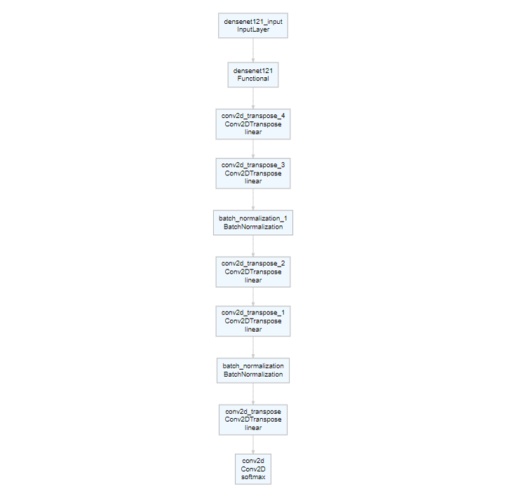

- sieć *DeepLabV3* z wykorzystaniem *ResNet*

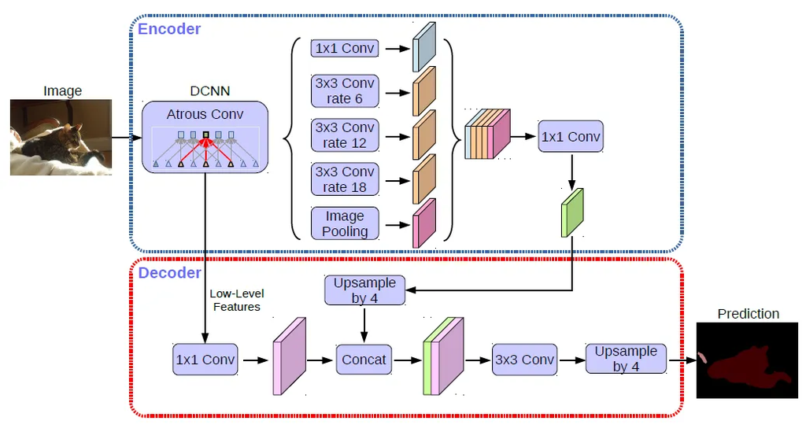

Przykład sieci DeepLabV3

- sieć U-net:

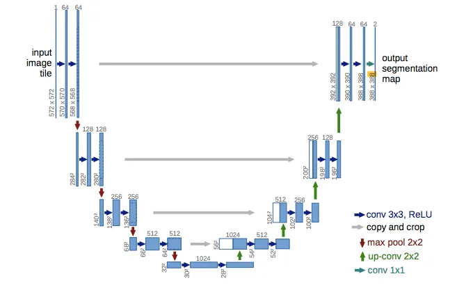

Przykład sieci U-net

**Informacja**

Z powodów obliczeniowych oraz dużego rozmiaru danych, cały proces modelowania wraz z opisem poszczególnych modeli dostępny jest w formie notatnika ipynb na platformie kaggle. Notatnik stanowi ważny załącznik do raportu i jest wraz z nim dołączony. [Link do notatnika](https://www.kaggle.com/code/pszyszka022/projekt-automatyczna-analiza-obrazu/)

Predykcja na 5 losowych obrazach ze zbioru testowego (obraz po prawej stronie jest predykcją, a w środku oryginalną maską):

**DenseNet121**

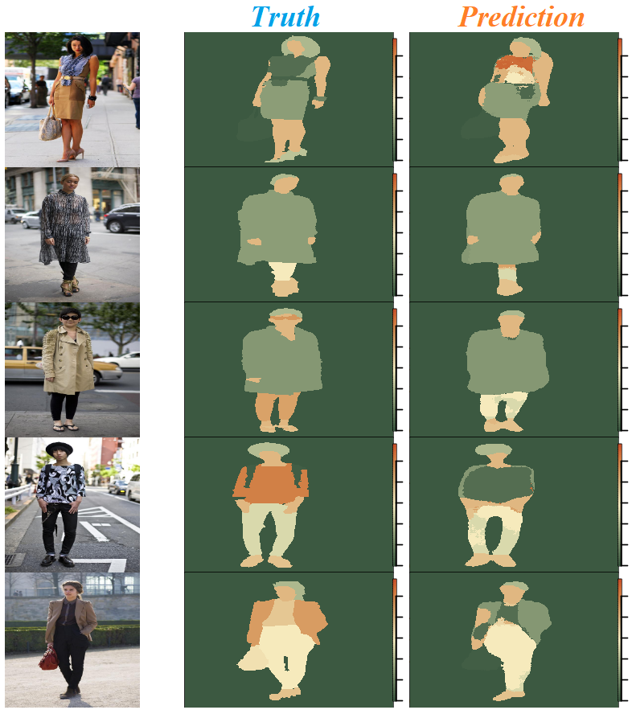

**DeepLabV3**

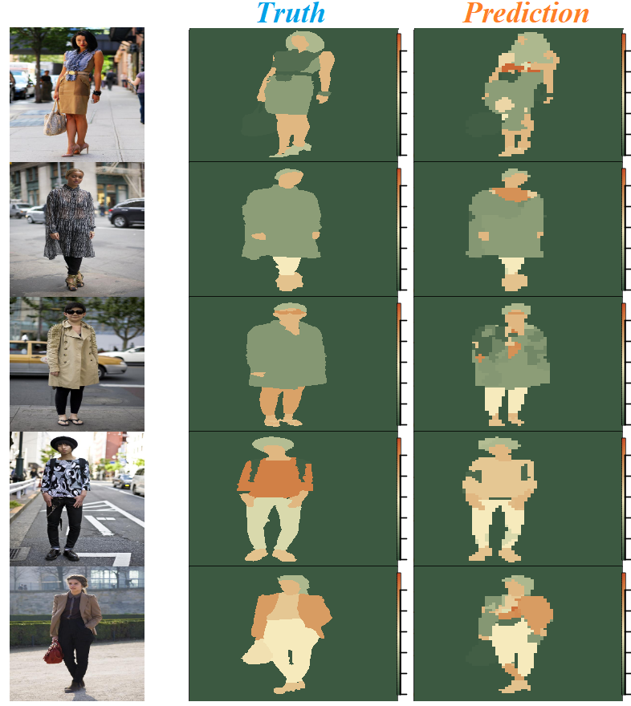

**U-Net**

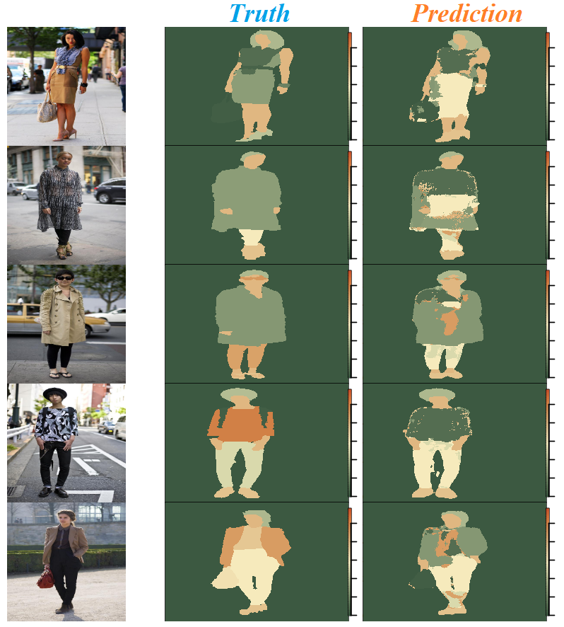

Ze zbudowanych modeli cieżko jest wyróżnić jest najlepszy. Wszystkie trzy radzą sobie dostatecznie dobrze w kontekście rozpoznawania kształtów, przy czym architektura w stylu `U-Net` zdaje się radzić z tym najlepiej.

# Podsumowanie

Problem segmentacji części garderoby dla tego zbioru danych jest wymagający. Ograniczenie w postaci tak małej liczby obserwacji, przy dużej liczbie samych klas ubioru i braku możliwości augmentacji, znacząco wpływa na problemy związane z jakością dopasowania. Niemniej jednak udało się opracować takie architektury, które w satysfakcjonującym stopniu radzą sobie z zadaniem. W przypadku gdyby zbiór był kilkakrotnie większy, prawdopodobnie każda z przedstawionych architektur poradziłaby sobie bez żadnych problemów.